# Simple Linear Regression

```r
# Load your libraries
library(mosaic)
library(ResourceSelection)
library(pander)
library(tidyverse)
library(car)
library(DT)

weather <- read.csv("../../Data/MyLinearRegressionData.csv")
weather <- weather%>%
  mutate(Date = as.Date(Date, "%m/%d/%Y"))
```

## Background

### Data

The data in this analysis was collected from accuweather.com. We’re using the highs from every day from September 1st to November 3rd 2023.

### Research Question

The goal of this analysis is to predict future temperatures based on the weather over the last 2 months. Our research question is is there a linear correlation between weather and time?

## Analysis

### Hypotheses

$$H_0: \beta_1 = 0$$
$$H_\alpha: \beta_1 \neq 0$$
$$\alpha = .05$$

$\beta_1$ in this case is the slope of the trend line. If $\beta1=0$, then there is no linear relationship between temperature and day.

### Linear Regression

```r
#Perform the analysis
mylm <- lm(High_f ~ Date, data = weather)
b <- mylm$coefficients
pander(mylm)
```

Fitting linear model: High_f ~ Date

|  | Estimate | Std. Error | t value | Pr(>\|t\|) |
| --- | --- | --- | --- | --- |
| **(Intercept)** | 9903 | 1148 | 8.629 | 3.223e-12 |
| **Date** | -0.5011 | 0.05846 | -8.572 | 4.056e-12 |

This linear regression is modeled by the equation:
$$Y_i = 9903 + -0.501X_i + \epsilon_i$$

Where $Y_i$ is the temperature high on a given day and $X_i$ is the day.

### Plot

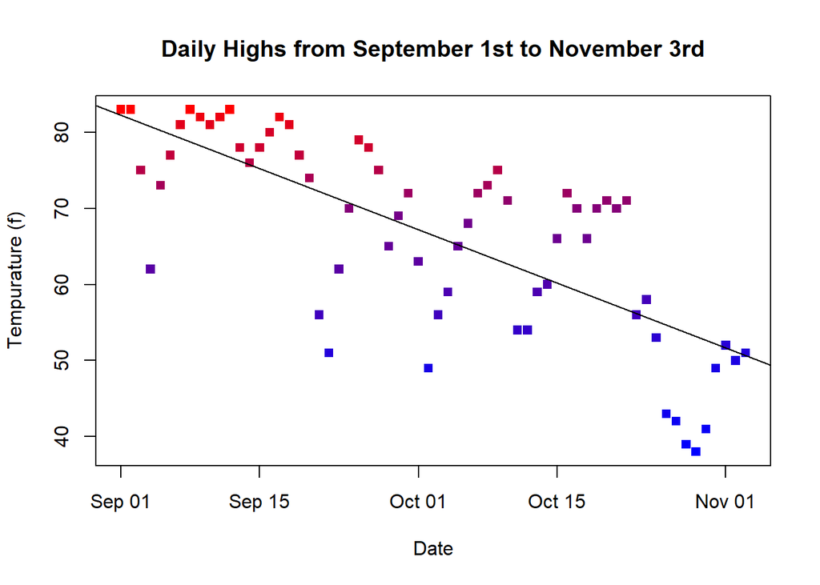

```r
#Plot the data
pal = colorRampPalette(c("blue", "red"))
weather$order = findInterval(weather$High_f, sort(weather$High_f))

plot(
  High_f ~ Date,
  data = weather,
  col=pal(nrow(weather))[weather$order],
  pch = 15,
  xlab = "Date",
  ylab = "Tempurature (f)",
  main = "Daily Highs from September 1st to November 3rd"
)
abline(mylm)
```

### Check Assumptions

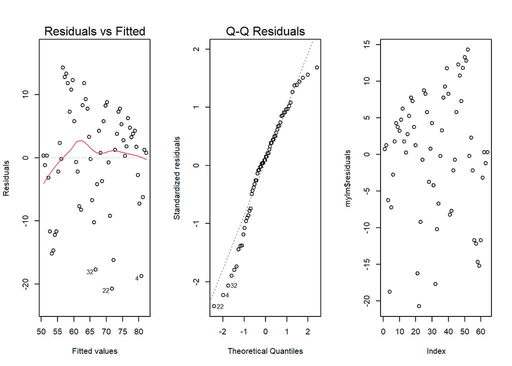

```r
#Check assumptions
par(mfrow=c(1,3))
plot(mylm,which=1:2)
plot(mylm$residuals)
```

The Residuals vs Fitted graph (left) gives us reason to believe there is a non-linear correlation between temperature and date. The QQ plot looks good, but the Residuals vs Order plot also gives us concern that the error terms are dependent instead of independent.

## Conclussion

With a p-value below our confidence level, there is evidence that there is a meaningful correlation between date and temperature. In other words, there is a statistical connection between date and daily highs between September 1st and November 3rd. However, the relationship does not appear to be linear.

## Appendix

```r
datatable(weather, options=list(lengthMenu = c(3,10,30)), extensions="Responsive")
```

|  | Date | High_f | order |
| --- | --- | --- | --- |
| 1 | 2023-09-01 | 83 | 64 |
| 2 | 2023-09-02 | 83 | 64 |
| 3 | 2023-09-03 | 75 | 46 |
| 4 | 2023-09-04 | 62 | 23 |
| 5 | 2023-09-05 | 73 | 42 |
| 6 | 2023-09-06 | 77 | 49 |
| 7 | 2023-09-07 | 81 | 57 |
| 8 | 2023-09-08 | 83 | 64 |
| 9 | 2023-09-09 | 82 | 60 |
| 10 | 2023-09-10 | 81 | 57 |

[output cut: 54 more lines]